# Data Inventory & Well/Facility Flow Network

## Purpose and Scope

This notebook is the living reference for two threads that, unlike the conductivity/sampling-frequency workstream (`01_conductivity_temporal_structure.qmd`), don’t have a single home yet: **(1)** what data currently exists in the database and over what time span, and **(2)** the production well -> port -> injection well flow network (Dhakal et al. 2025) plus the raw NDWR well-log records that back up individual well identities/construction. Update this notebook, not just the underlying scripts, as both threads evolve – consistent with this project’s convention for `01`.

```r
library(DBI)
library(RSQLite)
library(dplyr)
library(ggplot2)
db_path <- file.path("database", "geochem_operational.sqlite")
if (!file.exists(db_path)) db_path <- file.path("..", "database", "geochem_operational.sqlite")
con <- dbConnect(SQLite(), db_path)
source_path <- file.path("scripts", "analysis", "data_availability.R")
if (!file.exists(source_path)) source_path <- file.path("..", "scripts", "analysis", "data_availability.R")
source(source_path)
```

## 1. Data Availability Through Time

`scripts/analysis/data_availability.R` computes, for every major dated table, the earliest/latest record and count. It handles each table’s own date-storage convention – and, notably, discovered that `Sampling_Events.date` mixes **two different numeric epoch conventions** within the same column (Excel-serial-from-1899-12-30 for recent rows, Unix-epoch-days-from-1970-01-01 for ~723 older rows) – a real, previously-undiscovered data bug, not something introduced by this notebook. `external_event_id` (e.g. `"SB10_1987-10-21"`) reliably encodes the true date and is used as ground truth wherever available; only ~10 of 759 rows lack that suffix and still rely on the ambiguous numeric column.

```r
avail <- compute_data_availability(con)
avail
```

```
# A tibble: 7 × 5
  source                                category start_date end_date   n_records
  <chr>                                 <chr>    <date>     <date>         <int>
1 Chemistry Sampling Events             Discret… 1950-01-01 2026-05-01      1452
2 Water Level Observations              Discret… 1952-06-25 2026-01-01    153736
3 USGS Historic Specific Conductance (… Discret… 1971-07-28 2001-02-07        73
4 NOAA Weather Observations             Externa… 2001-08-08 2026-09-24     43197
5 USGS Discharge (live, param 60)       Continu… 2025-01-01 2026-06-06    272039
6 Temperature Logger Observations       Continu… 2025-10-01 2026-08-22    204622
7 Conductivity Logger Observations      Continu… 2026-07-15 2026-08-22     21901
```

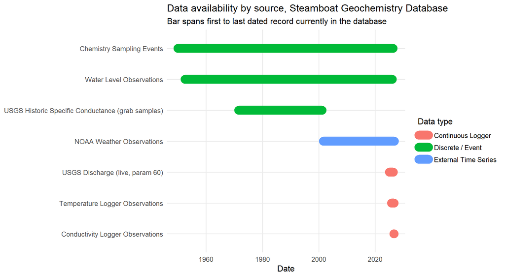

```r
plot_data_availability(avail)
```

**Known follow-up (not fixed here):** the root cause of the `Sampling_Events.date` dual-epoch bug – which ingest script wrote the Unix-epoch-day rows – has not been identified. `external_event_id` appears to be a reliable independent record of the true date for nearly all rows, but the underlying `date` column itself remains wrong for roughly 95% of rows and should not be trusted directly by any other script until traced and fixed at the source.

## 2. Well & Facility Flow Network

Production wells feed named commingling ports, which route to injection wells (Dhakal et al. 2025, Figure 5). `well_role` classifies each well; `vw_production_to_port` / `vw_port_to_injection` expose each leg of the network independently since the two legs are confirmed at different levels of confidence.

```r
dbGetQuery(con, "SELECT well_role, COUNT(*) n FROM Wells GROUP BY well_role ORDER BY n DESC")
```

```
   well_role   n
1    unknown 185
2 production  38
3    monitor  23
4  injection  13
5   domestic   5
```

```r
dbGetQuery(con, "SELECT * FROM vw_production_to_port")
```

```
   production_well_id production_well_name port_id port_name valid_from
1                  77                78-29       1  Galena 1       <NA>
2                  78                 HA-4       1  Galena 1       <NA>
3                  79                 PW-1       1  Galena 1       <NA>
4                  80                 PW-2       1  Galena 1       <NA>
5                  81                 PW-3       1  Galena 1       <NA>
6                  82               PW 2-1       4     SB2/3       <NA>
7                  83               PW 2-3       4     SB2/3       <NA>
8                  84               PW 2-5       4     SB2/3       <NA>
9                  85               PW 3-1       4     SB2/3       <NA>
10                 86               PW 3-2       4     SB2/3       <NA>
11                 87               PW 3-3       4     SB2/3       <NA>
12                 88               PW 3-4       4     SB2/3       <NA>
13                 89               14A-33       3  Galena 3       <NA>
14                 90                34-32       3  Galena 3       <NA>
```

[output cut: 89 more lines]

```r
dbGetQuery(con, "SELECT * FROM vw_port_to_injection")
```

```
   port_id port_name injection_well_id injection_well_name valid_from valid_to
1        1  Galena 1                74               45-28       <NA>     <NA>
2        4     SB2/3                74               45-28       <NA>     <NA>
3        1  Galena 1                75               35-28       <NA>     <NA>
4        4     SB2/3                75               35-28       <NA>     <NA>
5        1  Galena 1                76               46-28       <NA>     <NA>
6        4     SB2/3                76               46-28       <NA>     <NA>
7        1  Galena 1               101                IW-6       <NA>     <NA>
8        4     SB2/3               101                IW-6       <NA>     <NA>
9        3  Galena 3               104             23-33RD       <NA>     <NA>
10       3  Galena 3               105               43-33       <NA>     <NA>
11       5      SBHR               106              42A-32       <NA>     <NA>
12       3  Galena 3               106              42A-32       <NA>     <NA>
13       5      SBHR               107               21-32       <NA>     <NA>
14       3  Galena 3               107               21-32       <NA>     <NA>
```

[output cut: 33 more lines]

Both legs are real (transcribed directly from the Dhakal figure), but **not every well in either table yet has a coordinate** – see the GeoPackage’s `production_to_port`/`port_to_injection` line layers, which only draw a line where both endpoints are located. `PW-1/2/3`, `13-5R`, `21B-5R`, `83B-6R`, and `23-33RD` are the main remaining coordinate gaps as of this writing.

## 3. Well Logs: OCR Extraction, Identity Matching & Status History

- **`Well_Log_Documents`** – one row per log number (tracking both the primary scan and, when present, its “(2)” alternate on the same row), with OCR/cross-reference-derived location, depth, perforation, Section/Township/Range, type of work, proposed use, and hole/casing diameter.
- **`Well_Work_Events`** – one row per document once promoted/ registered, so a well’s status history (new -> deepened -> abandoned, etc.) is a real time series instead of a single overwritten snapshot.
- **`Well_Lithology`** – best-effort depth-interval descriptions staged from OCR text (`confidence = 'ocr_heuristic_unvalidated'`), joinable to perforation depth once a well is identified.

**Location extraction now has four fallback levels**, tried in order: a labeled Latitude/Longitude field, an unlabeled whole-text scan, UTM Easting/Northing conversion, and – new in Session 24 – a Bureau of Land Management PLSS (Section/Township/Range) lookup via their public CadNSDI REST service, used only when the first three all fail. When a log has both a primary and “(2)” alternate scan, lat/lon specifically merges by **extraction-confidence rank** (labeled field beats UTM beats unlabeled scan beats PLSS), not by “primary always wins” – a real bug caught during testing (logs `48594`/`126301`: the primary scan’s unlabeled-scan guess landed far outside Nevada, while the “(2)” alt scan had a properly labeled field).

```r
dbGetQuery(con, "
  SELECT
    (SELECT COUNT(*) FROM Well_Log_Documents) AS n_documents,
    (SELECT COUNT(*) FROM Well_Log_Documents WHERE match_method = 'duplicate_content_skipped') AS n_duplicate_content,
    (SELECT COUNT(*) FROM Well_Log_Documents WHERE plss_latlon_method = 'plss_section_centroid') AS n_plss_derived,
    (SELECT COUNT(*) FROM Well_Work_Events) AS n_work_events,
    (SELECT COUNT(*) FROM Well_Lithology) AS n_lithology_intervals,
    (SELECT COUNT(DISTINCT well_id) FROM Well_Work_Events WHERE work_type = 'abandonment') AS n_wells_flagged_abandoned
")
```

```
  n_documents n_duplicate_content n_plss_derived n_work_events
1          65                   1              3            42
  n_lithology_intervals n_wells_flagged_abandoned
1                    79                        17
```

**Type of work and proposed use**, extracted per document, give a quick sense of what this batch actually contains:

```r
dbGetQuery(con, "
  SELECT work_type, proposed_use, COUNT(*) n
  FROM Well_Log_Documents
  GROUP BY work_type, proposed_use
  ORDER BY n DESC
")
```

```
     work_type proposed_use  n
1         <NA>         <NA> 16
2  abandonment      monitor 11
3    deepening     domestic 11
4    deepening      monitor 10
5         <NA>     domestic  5
6  abandonment   industrial  5
7         <NA>      monitor  4
8         <NA>   industrial  1
9         <NA>        stock  1
10 abandonment   geothermal  1
```

**Well status for mapping (production/injection/monitoring/P&A):** rather than overloading `Wells.well_role` (a well’s *role* doesn’t stop being “injection” just because it’s later plugged), `vw_wells_gis` adds a derived `display_status` column: a well shows as “Plugged & Abandoned” if it has any `Well_Work_Events` row with `work_type = 'abandonment'`, otherwise it falls back to `well_role`. This is the field the website’s leaflet maps and the GeoPackage `wells` layer now color by.

```r
dbGetQuery(con, "SELECT display_status, COUNT(*) n FROM vw_wells_gis GROUP BY display_status ORDER BY n DESC")
```

```
     display_status   n
1           unknown 106
2        production  37
3 plugged_abandoned  17
4         injection  12
5           monitor  10
6          domestic   3
```

**Important, explicitly documented limitation:** this only captures P&A status where a `Well_Work_Events` row exists (i.e. a driller’s report OCR found “abandonment” as its type of work). Wells known to be P&A only from earlier sessions’ free-text prose (e.g. `64-32`, `IW-3` – see AGENTS.md) will NOT show as P&A under this logic unless a `Well_Work_Events` row is added for them – deliberately not guess-parsed from notes fields, to avoid false positives.

**Worked example – why proximity alone is misleading:** log `123802` sits only ~19.5 m from NBMG’s “Industrial Production Well 43-33,” the closest lat/lon match found across the original 12 logs. But `123802`’s own NDWR record shows it was completed **9/24/2015**, while 43-33 was drilled in **2007** – an 8-year gap that rules out the match despite the tight spatial coincidence. The same location-*and*-date discipline applies to every new candidate from the larger batch – `qc_well_log_matches()` now produces a standing, regenerable candidates report (`data/derived/well_log_match_candidates.csv`) with a plain- English **recommendation** per row (e.g. “download the NDWR”(2)” page”, “review as a close match”, or “no confident match – keep unresolved”), replacing the earlier one-off conversation-driven writeup per batch:

```r
cand_path <- file.path("data", "derived", "well_log_match_candidates.csv")
if (!file.exists(cand_path)) cand_path <- file.path("..", "data", "derived", "well_log_match_candidates.csv")
if (file.exists(cand_path)) read.csv(cand_path) else cat("No candidates report found.")
```

```
  document_id log_number well_name_parsed latitude longitude match_method
1          61      80672                  39.52525 -119.7046  parsed_text
2          31     146403         NVGD-MW1 40.33780 -719.4226
     plss_latlon_method work_type proposed_use has_alt_scan  nearest_well_name
1 plss_section_centroid                monitor        FALSE   Greg Street Well
2                       deepening      monitor        FALSE Sparks Avenue Well
  nearest_well_dist_m nearest_location_name nearest_location_dist_m
1              4503.2      Greg Street Well                  4503.2
2           9272835.1    Sparks Avenue Well               9272835.1
                                                                                                                                                                                                                      recommendation
1   Consider downloading NDWR's reformatted/streamlined PDF page for log #80672 and saving it as '80672(2).pdf' for easier parsing/cross-checking. | No confident match found (nearest candidate is far) -- keep unresolved for now.
2 Consider downloading NDWR's reformatted/streamlined PDF page for log #146403 and saving it as '146403(2).pdf' for easier parsing/cross-checking. | No confident match found (nearest candidate is far) -- keep unresolved for now.
                                                                                                                                                                                                                                                                  flags
1 no lat/lon, UTM found -- derived from PLSS Section/Township/Range section centroid via BLM PLSS CadNSDI (~800 m resolution); verify against a tighter source before trusting for anything precision-sensitive | well_name not confidently extracted -- check manually
2                                                                                                                              longitude -719.422608 is outside a Nevada sanity range -- likely OCR error (e.g. a misread leading digit), verify against the source PDF
```

No identity is written to `well_log_document_map.csv` for any unmatched log without a human confirming it first – both remaining candidates above are left unresolved deliberately (one, log `80672`, sits 4.5 km from its nearest named well – far too distant to treat as a match).

Because none of the newly-processed logs cleared the bar for a confident identity match, each with a real coordinate is registered as its own **provisional** `Wells` row (see `register_provisional_well_logs()` in `scripts/ingest/ingest_well_logs.R`) so the real coordinate/depth/ construction data is visible and mappable rather than stranded in the staging table – clearly named and flagged as unconfirmed, not silently merged into any named well:

```r
dbGetQuery(con, "
  SELECT well_id, well_name, latitude, longitude, total_depth,
         top_perforation, bottom_perforation, diameter_in, coordinate_source, coordinate_uncertainty_m
  FROM Wells
  WHERE well_name LIKE 'Unidentified Well%'
  ORDER BY well_id
")
```

```
   well_id                           well_name latitude longitude total_depth
1      112 Unidentified Well (NDWR Log 102799) 39.38797 -119.7477          NA
2      113 Unidentified Well (NDWR Log 103616) 39.40739 -119.7547         552
3      114 Unidentified Well (NDWR Log 123802) 39.38400 -119.7445          NA
4      115 Unidentified Well (NDWR Log 125850) 39.38952 -119.7670          NA
5      116 Unidentified Well (NDWR Log 125851) 39.38822 -119.7675          NA
6      117  Unidentified Well (NDWR Log 27731) 39.39797 -119.7538           3
7      118  Unidentified Well (NDWR Log 27732) 39.39436 -119.7538           3
8      145 Unidentified Well (NDWR Log 104216) 39.37058 -119.7570        1990
9      146  Unidentified Well (NDWR Log 10896) 39.39436 -119.7500          NA
10     147 Unidentified Well (NDWR Log 126275) 39.39862 -119.7300          NA
11     148 Unidentified Well (NDWR Log 126301) 39.39992 -119.7300         188
12     149 Unidentified Well (NDWR Log 129060) 39.40675 -119.7464          NA
13     150 Unidentified Well (NDWR Log 138973) 39.39712 -119.7400          NA
14     151 Unidentified Well (NDWR Log 138974) 39.39714 -119.7400          NA
```

[output cut: 135 more lines]

## 4. NDOM Well-Permit Cross-Validation

NDOM (Nevada Division of Minerals) supplied the official state permit record for every Ormat Steamboat well – an independent source from the NBMG/ArcGIS-digitized coordinates used elsewhere in this project. `ingest_ndom_wells.R` matches each of the 49 permitted wells to an existing `Wells` row (exact name, a confirmed spelling variant, or an existing alias), or registers it as a new provisional well when no match exists.

```r
dbGetQuery(con, "
  SELECT match_method, COUNT(*) n
  FROM NDOM_Well_Records
  GROUP BY match_method
  ORDER BY n DESC
")
```

```
  match_method  n
1   exact_name 42
2        alias  7
```

**Coordinate cross-validation:** where a well already had a coordinate from an earlier source, NDOM’s is compared against it – disagreements over 100 m are never auto-applied, only logged for manual review:

```r
disc_path <- file.path("data", "derived", "ndom_coordinate_discrepancies.csv")
if (!file.exists(disc_path)) disc_path <- file.path("..", "data", "derived", "ndom_coordinate_discrepancies.csv")
if (file.exists(disc_path)) read.csv(disc_path) else cat("No discrepancy report found.")
```

```
  well_id well_name permit existing_lat existing_lon existing_coordinate_source
1     100      24-5    178     39.37309    -119.7645      nbmg_geothermal_wells
2     109    64A-32    560     39.38023    -119.7595      nbmg_geothermal_wells
3      91     34-32    578     39.38046    -119.7597      nbmg_geothermal_wells
4      89    14A-33    669     39.38499    -119.7451      nbmg_geothermal_wells
5     101      41-5   1261     39.37526    -119.7648      nbmg_geothermal_wells
6     108     21-32   1358     39.38993    -119.7686      nbmg_geothermal_wells
  existing_coordinate_uncertainty_m ndom_lat  ndom_lon distance_m
1                                50 39.36873 -119.7677      555.1
2                                50 39.38228 -119.7592      228.2
3                               100 39.38323 -119.7654      572.5
4                                50 39.38266 -119.7497      476.2
5                                50 39.37398 -119.7638      166.1
6                                50 39.38821 -119.7675      211.3
```

These gaps are large relative to this project’s usual ~50-75 m NBMG/ ArcGIS uncertainty and are worth a manual look – NDOM is the official permit-of-record coordinate. As of 2026-09-12, the discrepancy report also includes `existing_coordinate_source`/`existing_coordinate_ uncertainty_m` (all 6 current discrepancies trace back to `nbmg_geothermal_wells`), so a reviewer can immediately see where the currently-stored point came from without a separate lookup.

**A real, pre-existing unit bug was found via this ingestion**: `elevation_m` on both `Wells` and `Locations` had been storing raw feet (inherited from `ingest_ndwr.R`) despite its name – e.g. “Sky Tavern Ski Resort” recorded as 7619, when Steamboat’s true elevation is ~1450-1750 m. Fixed at the source (`ingest_ndwr.R` now converts on insert) plus a one-time retroactive migration for already-populated rows:

```r
dbGetQuery(con, "
  SELECT 'Wells' AS tbl, MIN(elevation_m) min_m, MAX(elevation_m) max_m FROM Wells WHERE elevation_m IS NOT NULL
  UNION ALL
  SELECT 'Locations', MIN(elevation_m), MAX(elevation_m) FROM Locations WHERE elevation_m IS NOT NULL
")
```

```
        tbl    min_m    max_m
1     Wells 1243.584 2322.271
2 Locations 1344.564 2322.271
```

**Literature cross-check:** reading Dhakal et al. (2025) Table 1 (“Steamboat Production Well classification”) directly confirmed that `14-33` and `14A-33` are genuinely distinct wells (both listed separately under Middle Steamboat) – independent corroboration of the decision not to merge them, and the basis for adding `14-33` to the well/port network CSV (Galena 3, matching its sibling).

## 5. NDWR Spring/Stream Flow

Daily manual discharge readings (cfs) at NDWR-monitored spring/stream sites – first supplied 2026-09-12 for 4 sites on Whites Creek (Truckee Meadows basin, part of this project’s broader hydrologic context rather than the Steamboat outflow system itself).

```r
dbGetQuery(con, "
  SELECT l.name, l.latitude, l.longitude, l.elevation_m,
         COUNT(*) n_obs, MIN(s.date) start_date, MAX(s.date) end_date
  FROM Stream_Flow_Observations s
  JOIN Locations l ON l.location_id = s.location_id
  GROUP BY l.location_id
  ORDER BY l.name
")
```

```
                                            name latitude longitude elevation_m
1                       Whites Creek Above MRWTP 39.38837 -119.8147    1689.506
2                Whites Creek Below Mt. Rose WTP 39.38846 -119.8147    1689.506
3 Whites Creek Diversion to Mt. Rose WTP (MRWTP) 39.38837 -119.8147    1689.506
4                           Whites Creek at I580 39.42423 -119.7547    1386.840
  n_obs start_date   end_date
1   821 2020-12-19 2026-06-30
2  1004 2022-04-01 2026-03-31
3   913 2023-07-01 2026-03-31
4  2191 2017-12-30 2026-03-31
```

## 6. Chemistry by Sampling Port

The six NDEP PRR “outlet” composite samples staged since Session 3-6 (`Galena 1/2/3 Outlet`, `SB2 Outlet`, `SB3 Outlet`, `SBHR Outlet` – see `docs/action_items_for_user.md`’s earlier notes) were promoted for the first time this session, using the `Sampling_Ports` table’s own real coordinates (ArcGIS facility-polygon centroids from `register_facility_areas.R`) as the location, since no independent coordinate exists for the individual outlet taps themselves.

```r
port_source_path <- file.path("scripts", "analysis", "port_chemistry_summary.R")
if (!file.exists(port_source_path)) port_source_path <- file.path("..", port_source_path)
source(port_source_path)
result <- compute_port_chemistry_summary(con)
```

```
---- Computing chemistry-by-sampling-port summary ----
```

```
  -> No individual production/injection well has both a location and chemistry yet -- well_level is empty by design, not a bug (see header comment).
```

```
  -> 45 port x analyte summary row(s) from 5 port(s), n=2/4 sample date(s) each.
```

```r
result$by_port
```

```
# A tibble: 45 × 6
   port_name analyte        n  mean   min   max
   <chr>     <chr>      <int> <dbl> <dbl> <dbl>
 1 Galena 1  Alkalinity     2 536.  536.  536.
 2 Galena 1  B              2  30    30    30
 3 Galena 1  Ca             2  24.5  24    25
 4 Galena 1  Cl             2 805   750   860
 5 Galena 1  K              2  43.5  43    44
 6 Galena 1  Mg             2   1.6   0.7   2.5
 7 Galena 1  Na             2 690   660   720
 8 Galena 1  SO4            2 140   120   160
 9 Galena 1  SiO2           2 135   130   140
10 Galena 2  Alkalinity     2 469.  463.  475.
# ℹ 35 more rows
```

Real, thermal-signature chemistry (Cl 740-860 mg/L, Na 640-720 mg/L) now backs every one of the five named ports for the first time – but **n = 2 sample dates per port** (n = 4 for `SB2/3`, fed by two distinct outlet taps), from a single 2024 semi-annual submittal. That is too few to report a standard deviation or trust as a seasonal average, so the figure below shows every real point rather than just a mean, and the summary table above deliberately omits any variance statistic.

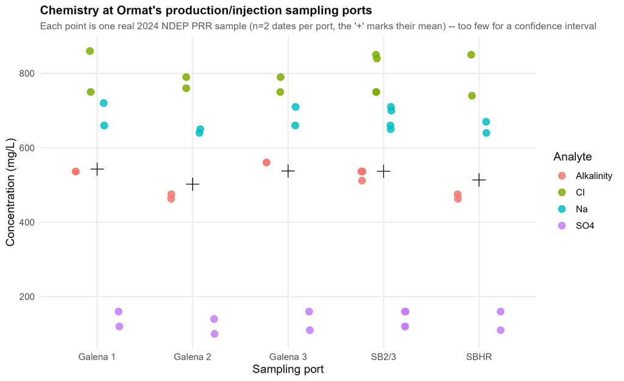

Real chemistry at each Ormat sampling port, n=2 (n=4 for SB2/3) sample dates per port, 2024 NDEP PRR submittal.

**These six samples are not PHREEQC-eligible.** The 2024 semi-annual submittal that is their sole source never recorded field pH or temperature for these outlet taps, and this project’s PHREEQC pipeline only ever pulls pH/temperature from the *same* `sample_id`’s own rows (no cross-location/date borrowing) – so all 12 (2 dates x 6 stations) correctly show up in `get_phreeqc_eligible()`’s rejected list with the reason `"missing temperature; missing pH"`. A real fix for this fixed project-wide, incidentally, while promoting this data: `vw_major_ions`’s analyte filter previously listed a literal `'HCO3'` code only, never this project’s own standard `'Alkalinity'` code (Session 15-16’s convention) – silently excluding 736 real Alkalinity rows from every prior sample, not just these six, from the major-ions view. Fixed additively.

**Also checked, and correctly empty today:** a second, best-effort join through `Production_Port_Links` -> `Wells` -> chemistry, so that individual production/injection well chemistry would automatically roll up into this same port-level summary the moment it exists. As of this writing, zero production/injection wells have both a populated `Wells.location_id` and any real chemistry, so `well_level` in `compute_port_chemistry_summary()`’s return value is empty by design, not a bug.

```r
result$well_level
```

```
[1] port_name well_name analyte   value     units
<0 rows> (or 0-length row.names)
```

## Changelog

[output not shown]